# Lab 4

Nicholas Heger

10/11/2020

## Part 1

1. The player names and opponent names are factors.

```r
defClean <- defense
defClean$Name <- as.factor(defClean$Name)
defClean$Opponent_Opponent <- as.factor(defClean$Opponent_Opponent)
offClean <- offense
offClean$Name <- as.factor(offClean$Name)
offClean$Opponent_Opponent <- as.factor(offClean$Opponent_Opponent)
bioClean <- biography
bioClean$Name <- as.factor(bioClean$Name)
str(defClean)
```

```
## tibble [502 x 11] (S3: tbl_df/tbl/data.frame)
##  $ Name             : Factor w/ 43 levels "Akers, Landen",..: 40 40 40 40 40 40 40 40 40 40 ...
##  $ Opponent_Opponent: Factor w/ 13 levels "Baylor","Iowa",..: 12 2 11 1 8 13 10 7 6 9 ...
##  $ Tackles_Solo     : chr [1:502] "4" "4" "3" "4" ...
##  $ Tackles_ASST     : chr [1:502] "4" "7" "5" "2" ...
##  $ Tackles_TFL      : chr [1:502] "0" "0" "0" "0" ...
##  $ Tackles_Sack     : chr [1:502] "0" "0" "0" "0" ...
##  $ Turnover_FF      : chr [1:502] "0" "0" "0" "0" ...
##  $ Turnover_FR      : chr [1:502] "0" "0" "0" "0" ...
##  $ Turnover_INT     : chr [1:502] "0" "0" "1" "0" ...
##  $ Pass_QBH         : chr [1:502] "1" "0" "0" "0" ...
##  $ Pass_PB          : chr [1:502] "1" "2" "0" "0" ...
```

```r
str(offClean)
```

```
## tibble [195 x 12] (S3: tbl_df/tbl/data.frame)
##  $ Name             : Factor w/ 17 levels "Akers, Landen",..: 1 1 1 1 1 1 1 1 1 1 ...
##  $ Opponent_Opponent: Factor w/ 13 levels "Baylor","Iowa",..: 12 2 11 1 8 13 10 7 6 9 ...
##  $ Rushing_ATT      : chr [1:195] "0" "0" "1" "0" ...
##  $ Rushing_YDS      : chr [1:195] "0" "0" "8" "0" ...
##  $ Rushing_TD       : chr [1:195] "0" "0" "0" "0" ...
##  $ Receiving_REC    : chr [1:195] "1" "0" "0" "0" ...
##  $ Receiving_YDS    : chr [1:195] "21" "0" "0" "0" ...
##  $ Receiving_TD     : chr [1:195] "0" "0" "0" "0" ...
##  $ Passing_CMP-ATT  : chr [1:195] NA NA NA NA ...
##  $ Passing_YDS      : chr [1:195] NA NA NA NA ...
##  $ Passing_TD       : chr [1:195] NA NA NA NA ...
##  $ Passing_INT      : chr [1:195] NA NA NA NA ...
```

```r
str(bioClean)
```

```
## tibble [105 x 7] (S3: tbl_df/tbl/data.frame)
##  $ Name      : Factor w/ 105 levels "Akers, Landen",..: 1 2 3 4 5 6 7 8 9 10 ...
##  $ Position  : chr [1:105] "Wide Receiver" "Tight End" "Wide Receiver" "Placekicker" ...
##  $ Height    : chr [1:105] "6-0" "6-7" "6-5" "6-0" ...
##  $ Weight    : chr [1:105] "188" "245" "204" "195" ...
##  $ Class     : chr [1:105] "Redshirt Senior" "Redshirt Senior" "Redshirt Freshman" "Redshirt Senior" ...
##  $ Hometown  : chr [1:105] "Cedar Rapids, Iowa" "Nixa, Mo." "Seffner, Fla." "Naperville, Ill." ...
##  $ Highschool: chr [1:105] "Washington" "Nixa" "Armwood" "Central" ...
```

2. All offensive and defensive statistics are numerical. The Weight column in biography is also numeric. (Optional: Learn to mutate multiple columns systematically using the ?across function in `dplyr)

```r
defClean[, 3:11] <- apply(defClean[, 3:11], 2, function(x) as.numeric(x))
offClean[, 3:12] <- apply(offClean[, 3:12], 2, function(x) as.numeric(x))
str(defClean)
```

```
## tibble [502 x 11] (S3: tbl_df/tbl/data.frame)
##  $ Name             : Factor w/ 43 levels "Akers, Landen",..: 40 40 40 40 40 40 40 40 40 40 ...
##  $ Opponent_Opponent: Factor w/ 13 levels "Baylor","Iowa",..: 12 2 11 1 8 13 10 7 6 9 ...
##  $ Tackles_Solo     : num [1:502] 4 4 3 4 3 1 7 3 6 5 ...
##  $ Tackles_ASST     : num [1:502] 4 7 5 2 2 1 1 2 1 5 ...
##  $ Tackles_TFL      : num [1:502] 0 0 0 0 1 0 0 0 1 1 ...
##  $ Tackles_Sack     : num [1:502] 0 0 0 0 0 0 0 0 0 1 ...
##  $ Turnover_FF      : num [1:502] 0 0 0 0 0 0 0 0 0 0 ...
##  $ Turnover_FR      : num [1:502] 0 0 0 0 0 0 0 0 0 0 ...
##  $ Turnover_INT     : num [1:502] 0 0 1 0 0 0 0 0 1 0 ...
##  $ Pass_QBH         : num [1:502] 1 0 0 0 0 0 0 0 1 0 ...
##  $ Pass_PB          : num [1:502] 1 2 0 0 0 1 0 0 0 0 ...
```

```r
str(offClean)
```

```
## tibble [195 x 12] (S3: tbl_df/tbl/data.frame)
##  $ Name             : Factor w/ 17 levels "Akers, Landen",..: 1 1 1 1 1 1 1 1 1 1 ...
##  $ Opponent_Opponent: Factor w/ 13 levels "Baylor","Iowa",..: 12 2 11 1 8 13 10 7 6 9 ...
##  $ Rushing_ATT      : num [1:195] 0 0 1 0 0 0 0 0 0 0 ...
##  $ Rushing_YDS      : num [1:195] 0 0 8 0 0 0 0 0 0 0 ...
##  $ Rushing_TD       : num [1:195] 0 0 0 0 0 0 0 0 0 0 ...
##  $ Receiving_REC    : num [1:195] 1 0 0 0 1 0 0 4 0 1 ...
##  $ Receiving_YDS    : num [1:195] 21 0 0 0 32 0 0 39 0 7 ...
##  $ Receiving_TD     : num [1:195] 0 0 0 0 0 0 0 0 0 0 ...
##  $ Passing_CMP-ATT  : num [1:195] NA NA NA NA NA NA NA NA NA NA ...
##  $ Passing_YDS      : num [1:195] NA NA NA NA NA NA NA NA NA NA ...
##  $ Passing_TD       : num [1:195] NA NA NA NA NA NA NA NA NA NA ...
##  $ Passing_INT      : num [1:195] NA NA NA NA NA NA NA NA NA NA ...
```

3. Change the Height column in biography into numeric. (Hint: Use a unit that works well)

```r
bioClean <- biography %>%
  mutate(Weight = as.numeric(Weight)) %>%
  separate(Height, c('feet', 'inches'), sep='-') %>%
  mutate(feet = as.numeric(feet), inches = as.numeric(inches)) %>%
  mutate(Height_inches = (12*feet+inches)) %>%
  select(-feet, -inches)
str(bioClean)
```

```
## tibble [105 x 7] (S3: tbl_df/tbl/data.frame)
##  $ Name         : chr [1:105] "Akers, Landen" "Allen, Chase" "Anderson, Ezeriah" "Assalley, Connor" ...
##  $ Position     : chr [1:105] "Wide Receiver" "Tight End" "Wide Receiver" "Placekicker" ...
##  $ Weight       : num [1:105] 188 245 204 195 190 235 255 285 300 215 ...
##  $ Class        : chr [1:105] "Redshirt Senior" "Redshirt Senior" "Redshirt Freshman" "Redshirt Senior" ...
##  $ Hometown     : chr [1:105] "Cedar Rapids, Iowa" "Nixa, Mo." "Seffner, Fla." "Naperville, Ill." ...
##  $ Highschool   : chr [1:105] "Washington" "Nixa" "Armwood" "Central" ...
##  $ Height_inches: num [1:105] 72 79 77 72 72 75 74 74 72 78 ...
```

## Part 2

1. Reformat the defClean data frame into a tidy format using pivot_longer. The type of statistic (Tackles_Solo, Tackles_ASST, etc) is added as a new key column named stat.

```r
defClean_with_pivot <- pivot_longer(defClean, Tackles_Solo:Pass_PB, names_to = 'Defense_Skill', values_to = 'stat')
defClean_with_pivot
```

```
## # A tibble: 4,518 x 4
##    Name            Opponent_Opponent Defense_Skill  stat
##    <fct>           <fct>             <chr>         <dbl>
##  1 White, Lawrence UNI               Tackles_Solo      4
##  2 White, Lawrence UNI               Tackles_ASST      4
##  3 White, Lawrence UNI               Tackles_TFL       0
##  4 White, Lawrence UNI               Tackles_Sack      0
##  5 White, Lawrence UNI               Turnover_FF       0
##  6 White, Lawrence UNI               Turnover_FR       0
##  7 White, Lawrence UNI               Turnover_INT      0
##  8 White, Lawrence UNI               Pass_QBH          1
##  9 White, Lawrence UNI               Pass_PB           1
## 10 White, Lawrence Iowa              Tackles_Solo      4
## # ... with 4,508 more rows
```

2. Compare the distributions of the defensive statistics. What defensive skills are rare?

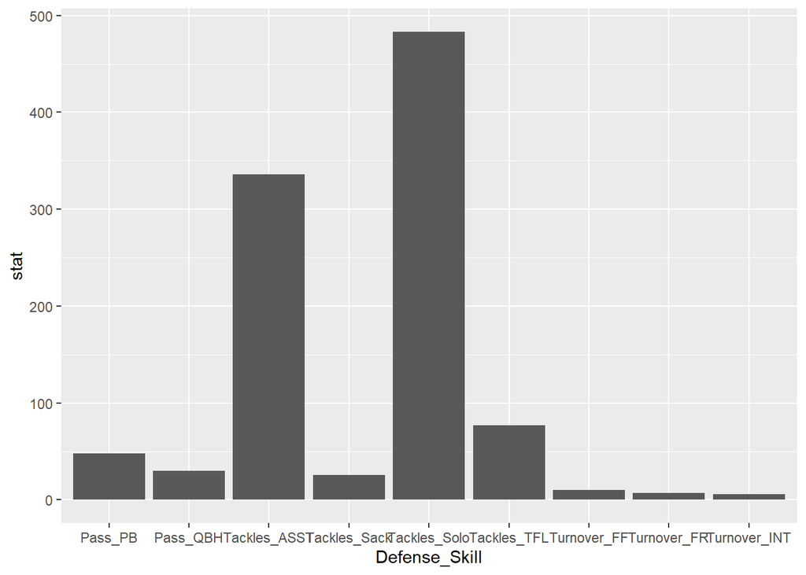

```r
ggplot(defClean_with_pivot, aes(x=Defense_Skill, y=stat)) + geom_bar(stat='identity')
```

All of the different 3 types of turnovers are rare, as seen in the above plot.

3. Did ISU have better defense against Iowa or Notre Dame? Answer this question by creating a scatterplot with x- and y-axes being the number of solo tackles (of each player). A large number of solo tackles is an indicator of good defense.

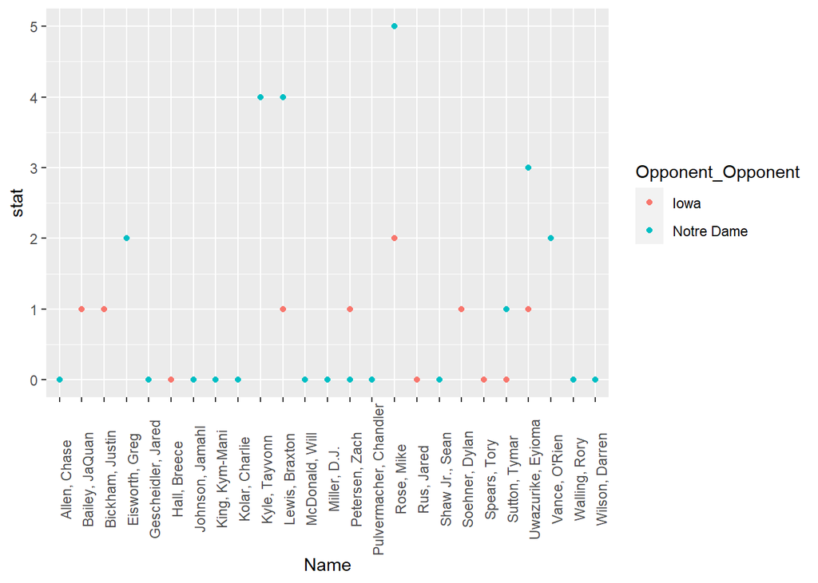

```r
defClean2 <- defClean_with_pivot %>%
  filter(Opponent_Opponent == c('Iowa', 'Notre Dame'),
         Defense_Skill == 'Tackles_Solo')
ggplot(defClean2, aes(x=Name, y=stat, color=Opponent_Opponent)) + geom_point() + theme(axis.text.x = element_text(angle = 90))
```

The Cyclones had better defense against Notre Dame, according the the above graph showing solo tackles.

4. Separate the Hometown column into two columns, namely the city and the state. Print the first few rows of these two columns. (Hint: look at the sep= argument of separate)

```r
bioClean <- separate(bioClean, Hometown, c('city', 'state'), sep=',')
bioClean
```

```
## # A tibble: 105 x 8
##    Name       Position   Weight Class     city    state Highschool Height_inches
##    <chr>      <chr>       <dbl> <chr>     <chr>   <chr> <chr>              <dbl>
##  1 Akers, La~ Wide Rece~    188 Redshirt~ Cedar ~ " Io~ Washington            72
##  2 Allen, Ch~ Tight End     245 Redshirt~ Nixa    " Mo~ Nixa                  79
##  3 Anderson,~ Wide Rece~    204 Redshirt~ Seffner " Fl~ Armwood               77
##  4 Assalley,~ Placekick~    195 Redshirt~ Naperv~ " Il~ Central               72
##  5 Azunna, A~ Defensive~    190 Redshirt~ Grand ~ " Te~ Lake Ridge            72
##  6 Bailey, C~ Defensive~    235 Redshirt~ Clarks~ " Mi~ Clarksdale            75
##  7 Bailey, J~ Defensive~    255 Redshirt~ Jackso~ " Fl~ Raines                74
##  8 Bailey, J~ Defensive~    285 Redshirt~ Jackso~ " Fl~ Raines                74
##  9 Bankston,~ Defensive~    300 Junior    Woodst~ " Ga~ Woodstock             72
## 10 Bouman, A~ Quarterba~    215 Freshman  Buffalo " Mi~ Buffalo               78
## # ... with 95 more rows
```

5. How many players are there from each state?

```r
table(bioClean$state)
```

```
##
##      Ariz.       Ark.  Australia     Calif.       Fla.        Ga.       Ill.
##          4          1          1          3         10          4          5
##       Iowa       Kan.      Mich.      Minn.      Miss.        Mo.       Ohio
##         35          3          4          4          1          6          7
##      Okla.        Pa.       S.D.      Texas       Wis.
##          2          1          2          6          6
```

## Part 3

1. Find which states do the ISU defensive and offensive players come from. Create an appropriate summary.

```r
biodef <- inner_join(bioClean, defClean, by='Name')
table(biodef$state)
```

```
##
##    Ark.  Calif.    Fla.     Ga.    Iowa    Kan.   Mich.     Mo.    Ohio   Okla.
##      12      23      43      33      80      12      13      24      33      24
##   Texas    Wis.
##      23      26
```

```r
biooff <- inner_join(bioClean, offClean, by='Name')
table(biooff$state)
```

```
##
##  Ariz.   Ark.   Fla.    Ga.   Ill.   Iowa   Kan.    Mo.   Ohio  Okla.  Texas
##     13     12     25     13      4     13     12     13     10     24     13
```

2. How does the performance of quarterback Brock Purdy relate to the performance of the ISU team?

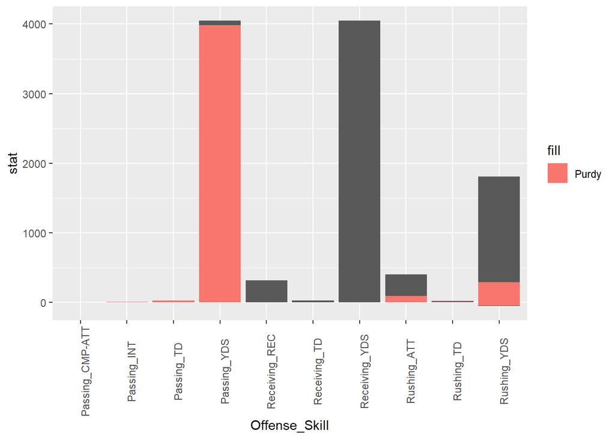

```r
purdy <- offClean %>%
  filter(Name == 'Purdy, Brock')
offClean_with_pivot <- pivot_longer(offClean, Rushing_ATT:Passing_INT, names_to = 'Offense_Skill', values_to = 'stat')
purdy_with_pivot <- pivot_longer(purdy, Rushing_ATT:Passing_INT, names_to = 'Offense_Skill', values_to = 'stat')
ggplot(offClean_with_pivot, aes(x=Offense_Skill, y=stat)) + geom_bar(stat='identity') + geom_bar(data=purdy_with_pivot, stat='identity', aes(fill = 'Purdy')) + theme(axis.text.x = element_text(angle = 90))
```

The above plot shows Brock Purdy’s stats in pink, with the rest of the team in black. We can see that Purdy’s performance in passing is much higher than the rest of the team, which is to be expected from the quaterback. Purdy also has a relatively high percentage of the team’s rushing yards. The team’s performance in receiving yards is also much higher than that of Purdy, also expected for a quaterback. I did not compare the performance of Brock Purdy to that of the defense because the quarterback is part of the offense.

3. Which ISU player(s) made big progress over the last year? Compare the 2019 and the 2018 data here.

```r
defClean2018 <- defense2018
defClean2018$Name <- as.factor(defClean2018$Name)
defClean2018$Opponent_Opponent <- as.factor(defClean2018$Opponent_Opponent)
offClean2018 <- offense2018
offClean2018$Name <- as.factor(offClean2018$Name)
offClean2018$Opponent_Opponent <- as.factor(offClean2018$Opponent_Opponent)
defClean2018[, 3:11] <- apply(defClean2018[, 3:11], 2, function(x) as.numeric(x))
offClean2018[, 3:12] <- apply(offClean2018[, 3:12], 2, function(x) as.numeric(x))
offClean2018_with_pivot <- pivot_longer(offClean2018, Rushing_ATT:Passing_INT, names_to = 'Offense_Skill', values_to = 'stat')
defClean2018_with_pivot <- pivot_longer(defClean2018, Tackles_Solo:Pass_PB, names_to = 'Defense_Skill', values_to = 'stat')
defClean2018_with_pivot$year='2018'
defClean_with_pivot$year='2019'
defClean2018_2019 = full_join(defClean2018_with_pivot, defClean_with_pivot)
offClean2018_with_pivot$year='2018'
offClean_with_pivot$year='2019'
offClean2018_2019 = full_join(offClean2018_with_pivot, offClean_with_pivot)
```

[figure not shown]

```r
ggplot(defClean2018_2019, aes(x=Defense_Skill, y=stat, fill=year)) + geom_bar(stat='identity') + theme(axis.text.x = element_text(angle = 90)) + facet_wrap(~Name)
```

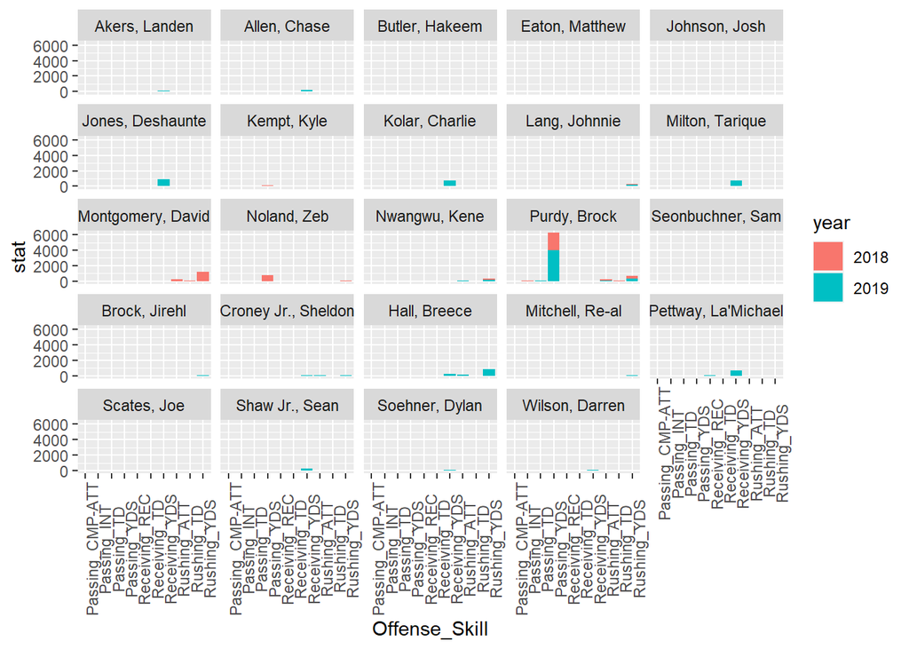

```r
ggplot(offClean2018_2019, aes(x=Offense_Skill, y=stat, fill=year)) + geom_bar(stat='identity') + theme(axis.text.x = element_text(angle = 90)) + facet_wrap(~Name)
```

The above charts show the improvement in players from 2018 to 2019. Many players had their ups and downs. A few that stick out are Eyioma Uwazurike and Vance O’Rien on the defense improved significantly, and on the offense Brock Purdy improved significantly.